# Project_Ensemble_Banking_TD_Subscription

#### Comparision between base model and its ensemble

```python
# To convert the list of dictionaries into a single dictionary
modr_dict=dict()
for i in model_results:
    for k,v in i.items():
        modr_dict[k]=v
```

```python
modr_df=pd.DataFrame(data=modr_dict, index=['BFR_TH_TRAIN_ACC','BFR_TH_TEST_ACC','BFR_TH_RECALL_SCORE','BFR_TH_F1_SCORE',
                                                 'TRAIN_AUC','TEST_AUC','OPT_TH',
                                            'AFT_TH_TEST_ACC','AFT_TH_RECALL_SCORE','AFT_TH_F1_SCORE']).T
modr_df
```

|  | BFR_TH_TRAIN_ACC | BFR_TH_TEST_ACC | BFR_TH_RECALL_SCORE | BFR_TH_F1_SCORE | TRAIN_AUC | TEST_AUC | OPT_TH | AFT_TH_TEST_ACC | AFT_TH_RECALL_SCORE | AFT_TH_F1_SCORE |
| --- | --- | --- | --- | --- | --- | --- | --- | --- | --- | --- |
| LogisticRegression | 0.7848 | 0.8874 | 0.2016 | 0.2953 | 0.7595 | 0.7350 | 0.2871 | 0.7325 | 0.5917 | 0.3411 |
| GaussianNB | 0.7503 | 0.8088 | 0.3693 | 0.3113 | 0.7365 | 0.7110 | 0.1108 | 0.6615 | 0.6541 | 0.3113 |
| KNeighborsClassifier | 0.9961 | 0.8343 | 0.3264 | 0.3155 | 1.0000 | 0.6673 | 0.3333 | 0.7703 | 0.4417 | 0.3103 |
| DecisionTreeClassifier | 0.8507 | 0.8548 | 0.2955 | 0.3227 | 0.8906 | 0.6767 | 0.2602 | 0.7399 | 0.5167 | 0.3173 |
| LogisticRegression-BaggingClassifier | 0.7845 | 0.8894 | 0.1871 | 0.2837 | 0.7566 | 0.7349 | 0.2794 | 0.7239 | 0.6112 | 0.3412 |
| GaussianNB-BaggingClassifier | 0.7530 | 0.8212 | 0.3296 | 0.3014 | 0.7336 | 0.7124 | 0.2006 | 0.6712 | 0.6358 | 0.3115 |
| KNeighborsClassifier-BaggingClassifier | 0.9864 | 0.8752 | 0.2495 | 0.3187 | 0.9992 | 0.7184 | 0.3868 | 0.8510 | 0.3491 | 0.3541 |
| DecisionTreeClassifier-BaggingClassifier | 0.9735 | 0.8837 | 0.2161 | 0.3030 | 0.9987 | 0.7105 | 0.3491 | 0.8540 | 0.3333 | 0.3483 |
| RandomForestClassifier | 0.9835 | 0.8577 | 0.2810 | 0.3161 | 0.9990 | 0.6993 | 0.4200 | 0.8380 | 0.3441 | 0.3320 |
| LogisticRegression-AdaBoostClassifier | 0.7844 | 0.8896 | 0.1916 | 0.2887 | 0.7590 | 0.7339 | 0.4991 | 0.7225 | 0.5999 | 0.3359 |
| GaussianNB-AdaBoostClassifier | 0.3482 | 0.3107 | 0.5583 | 0.1593 | 0.4831 | 0.4751 | 0.4773 | 0.2092 | 0.9030 | 0.2108 |
| DecisionTreeClassifier-AdaBoostClassifier | 0.9961 | 0.8535 | 0.2451 | 0.2814 | 1.0000 | 0.6458 | 0.4993 | 0.8528 | 0.2470 | 0.2819 |
| GradientBoostingClassifier | 0.9764 | 0.8751 | 0.2338 | 0.3046 | 0.9986 | 0.7059 | 0.2852 | 0.8422 | 0.3384 | 0.3342 |
| XGBClassifier | 0.9136 | 0.8879 | 0.1676 | 0.2591 | 0.9675 | 0.7297 | 0.1500 | 0.8169 | 0.4536 | 0.3671 |

Logistic Regression:

```python
modr_df.loc[['LogisticRegression','LogisticRegression-BaggingClassifier','LogisticRegression-AdaBoostClassifier']]
```

|  | BFR_TH_TRAIN_ACC | BFR_TH_TEST_ACC | BFR_TH_RECALL_SCORE | BFR_TH_F1_SCORE | TRAIN_AUC | TEST_AUC | OPT_TH | AFT_TH_TEST_ACC | AFT_TH_RECALL_SCORE | AFT_TH_F1_SCORE |
| --- | --- | --- | --- | --- | --- | --- | --- | --- | --- | --- |
| LogisticRegression | 0.7848 | 0.8874 | 0.2016 | 0.2953 | 0.7595 | 0.7350 | 0.2871 | 0.7325 | 0.5917 | 0.3411 |
| LogisticRegression-BaggingClassifier | 0.7845 | 0.8894 | 0.1871 | 0.2837 | 0.7566 | 0.7349 | 0.2794 | 0.7239 | 0.6112 | 0.3412 |
| LogisticRegression-AdaBoostClassifier | 0.7844 | 0.8896 | 0.1916 | 0.2887 | 0.7590 | 0.7339 | 0.4991 | 0.7225 | 0.5999 | 0.3359 |

Observations:

TEST_AUC - There is very minute difference between the base and its corresponding ensemble.  
AFT_TH_TEST_ACC - This is on higher side for base model. Around 1%.  
AFT_TH_RECALL_SCORE - This has increased in ensembles. particulary for Bagging classifier.  
AFT_TH_F1_SCORE - There is very minute difference between the base and its corresponding ensemble.  
Conclusion: Seems ensembling didnt have much impact in this case.

GaussianNB:

```python
modr_df.loc[['GaussianNB','GaussianNB-BaggingClassifier','GaussianNB-AdaBoostClassifier']]
```

|  | BFR_TH_TRAIN_ACC | BFR_TH_TEST_ACC | BFR_TH_RECALL_SCORE | BFR_TH_F1_SCORE | TRAIN_AUC | TEST_AUC | OPT_TH | AFT_TH_TEST_ACC | AFT_TH_RECALL_SCORE | AFT_TH_F1_SCORE |
| --- | --- | --- | --- | --- | --- | --- | --- | --- | --- | --- |
| GaussianNB | 0.7503 | 0.8088 | 0.3693 | 0.3113 | 0.7365 | 0.7110 | 0.1108 | 0.6615 | 0.6541 | 0.3113 |
| GaussianNB-BaggingClassifier | 0.7530 | 0.8212 | 0.3296 | 0.3014 | 0.7336 | 0.7124 | 0.2006 | 0.6712 | 0.6358 | 0.3115 |
| GaussianNB-AdaBoostClassifier | 0.3482 | 0.3107 | 0.5583 | 0.1593 | 0.4831 | 0.4751 | 0.4773 | 0.2092 | 0.9030 | 0.2108 |

Observations:

TEST_AUC - There is very minute improvement in bagging but it drastically got down in boosting when compared to base model.  
AFT_TH_TEST_ACC - There is very minute improvement in bagging but it drastically got down in boosting when compared to base model.  
AFT_TH_RECALL_SCORE - This has been spiked in boosting classifier. Model has concentrated too much on reducing FN and ignored others.  
AFT_TH_F1_SCORE - There is very minute improvement in bagging but it drastically got down in boosting when compared to base model.  
Conclusion: Seems ensembling didnt have much impact in this case.

KNN:

```python
modr_df.loc[['KNeighborsClassifier','KNeighborsClassifier-BaggingClassifier','KNeighborsClassifier-AdaBoostClassifier']]
```

|  | BFR_TH_TRAIN_ACC | BFR_TH_TEST_ACC | BFR_TH_RECALL_SCORE | BFR_TH_F1_SCORE | TRAIN_AUC | TEST_AUC | OPT_TH | AFT_TH_TEST_ACC | AFT_TH_RECALL_SCORE | AFT_TH_F1_SCORE |
| --- | --- | --- | --- | --- | --- | --- | --- | --- | --- | --- |
| KNeighborsClassifier | 0.9961 | 0.8343 | 0.3264 | 0.3155 | 1.0000 | 0.6673 | 0.3333 | 0.7703 | 0.4417 | 0.3103 |
| KNeighborsClassifier-BaggingClassifier | 0.9864 | 0.8752 | 0.2495 | 0.3187 | 0.9992 | 0.7184 | 0.3868 | 0.8510 | 0.3491 | 0.3541 |
| KNeighborsClassifier-AdaBoostClassifier | NaN | NaN | NaN | NaN | NaN | NaN | NaN | NaN | NaN | NaN |

Observations:

TEST_AUC - There is good improvement in bagging model when compared to base.  
AFT_TH_TEST_ACC - There is good improvement in bagging model when compared to base.  
AFT_TH_RECALL_SCORE - This has been reduced in bagging model.  
AFT_TH_F1_SCORE - Improved by using bagging.  
Conclusion: Bagging has a significant impact and performance has been improved when compared to base model.

Note: KNN can not be used for Adaboost

Decision Tree:

```python
modr_df.loc[['DecisionTreeClassifier','DecisionTreeClassifier-BaggingClassifier','DecisionTreeClassifier-AdaBoostClassifier']]
```

|  | BFR_TH_TRAIN_ACC | BFR_TH_TEST_ACC | BFR_TH_RECALL_SCORE | BFR_TH_F1_SCORE | TRAIN_AUC | TEST_AUC | OPT_TH | AFT_TH_TEST_ACC | AFT_TH_RECALL_SCORE | AFT_TH_F1_SCORE |
| --- | --- | --- | --- | --- | --- | --- | --- | --- | --- | --- |
| DecisionTreeClassifier | 0.8507 | 0.8548 | 0.2955 | 0.3227 | 0.8906 | 0.6767 | 0.2602 | 0.7399 | 0.5167 | 0.3173 |
| DecisionTreeClassifier-BaggingClassifier | 0.9735 | 0.8837 | 0.2161 | 0.3030 | 0.9987 | 0.7105 | 0.3491 | 0.8540 | 0.3333 | 0.3483 |
| DecisionTreeClassifier-AdaBoostClassifier | 0.9961 | 0.8535 | 0.2451 | 0.2814 | 1.0000 | 0.6458 | 0.4993 | 0.8528 | 0.2470 | 0.2819 |

Observations:

TEST_AUC - There is good improvement in bagging model when compared to base. But thats not the case with adaboost  
AFT_TH_TEST_ACC - There is good improvement in both bagging and boosting models when compared to base.  
AFT_TH_RECALL_SCORE - This has been reduced in both ensemble models.  
AFT_TH_F1_SCORE - Improved by using bagging but degraded using boosting.  
Conclusion: Bagging has a significant impact and performance has been improved when compared to base model.

### 7. Compare performances of all the models (5 marks)

#### Best model for each metric

```python
# To retrieve the best model for each metric and its corresponding value for it
for i in ['AFT_TH_TEST_ACC','TEST_AUC','AFT_TH_RECALL_SCORE','AFT_TH_F1_SCORE']:
    print("Model with highest ",i," is : ",modr_df[i].sort_values(ascending=False).head(1).index.values[0]," & its value is: ",modr_df[i].sort_values(ascending=False).head(1)[0])
```

```
Model with highest  AFT_TH_TEST_ACC  is :  DecisionTreeClassifier-BaggingClassifier  & its value is:  0.854
Model with highest  TEST_AUC  is :  LogisticRegression  & its value is:  0.735
Model with highest  AFT_TH_RECALL_SCORE  is :  GaussianNB-AdaBoostClassifier  & its value is:  0.903
Model with highest  AFT_TH_F1_SCORE  is :  XGBClassifier  & its value is:  0.3671
```

Above states that different classifiers have performed well in different metrics. Lets dig-in further and see.

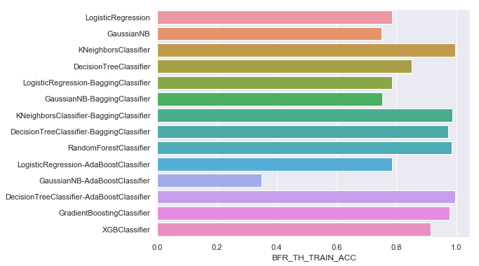

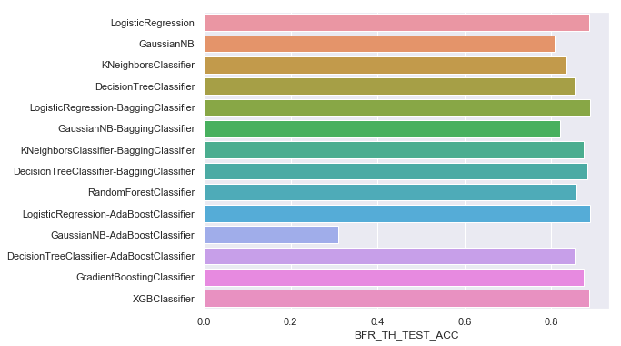

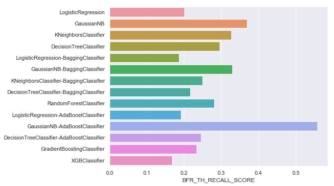

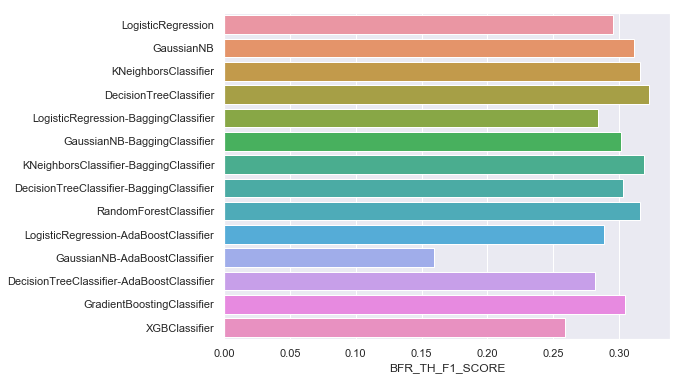

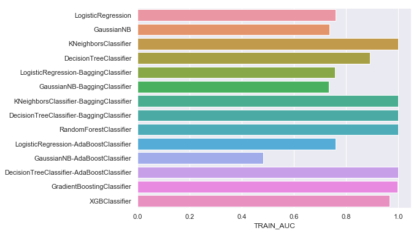

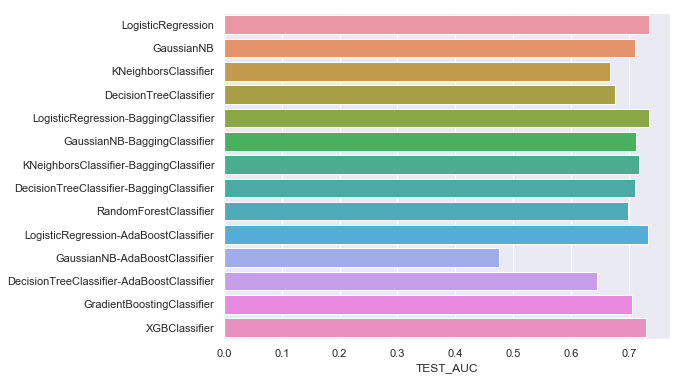

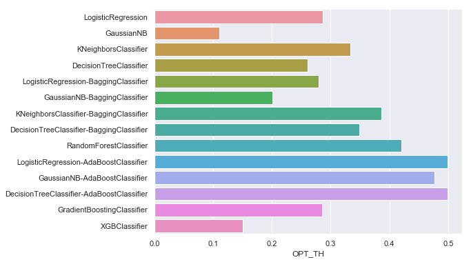

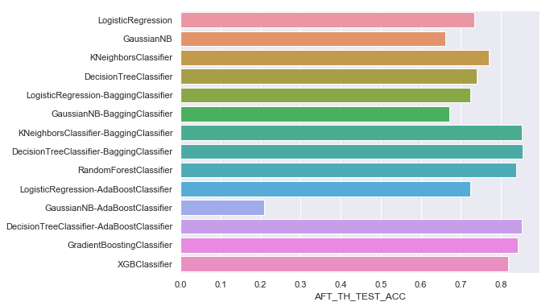

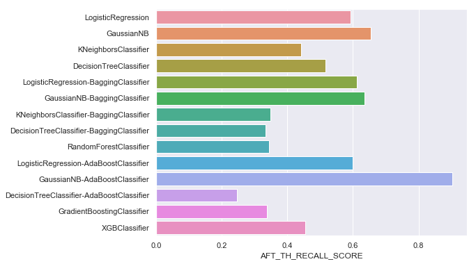

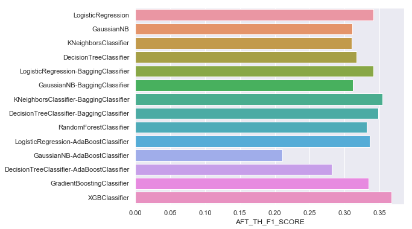

```python
count=0
for i in modr_df.columns:
    count=count+1
    plt.figure(count,figsize=(8,6))
    sns.barplot(x=modr_df[i], y=modr_df[i].index)
```

```python
# Lets get top 3 models in each metric and then do the voting.

print("Top 5 in AFT_TH_TEST_ACC:\n")
print(modr_df['AFT_TH_TEST_ACC'].sort_values(ascending=False).head(5))
print("---------------------------------------------------\n")
print("Top 5 in TEST_AUC:\n")
print(modr_df['TEST_AUC'].sort_values(ascending=False).head(5))
print("---------------------------------------------------\n")
print("Top 5 in AFT_TH_RECALL_SCORE:\n")
print(modr_df['AFT_TH_RECALL_SCORE'].sort_values(ascending=False).head(5))
print("---------------------------------------------------\n")
print("Top 5 in AFT_TH_F1_SCORE:\n")
print(modr_df['AFT_TH_F1_SCORE'].sort_values(ascending=False).head(5))
```

```
Top 5 in AFT_TH_TEST_ACC:

DecisionTreeClassifier-BaggingClassifier     0.8540
DecisionTreeClassifier-AdaBoostClassifier    0.8528
KNeighborsClassifier-BaggingClassifier       0.8510
GradientBoostingClassifier                   0.8422
RandomForestClassifier                       0.8380
Name: AFT_TH_TEST_ACC, dtype: float64
---------------------------------------------------

Top 5 in TEST_AUC:

LogisticRegression                        0.7350
LogisticRegression-BaggingClassifier      0.7349
LogisticRegression-AdaBoostClassifier     0.7339
XGBClassifier                             0.7297
KNeighborsClassifier-BaggingClassifier    0.7184
Name: TEST_AUC, dtype: float64
---------------------------------------------------

Top 5 in AFT_TH_RECALL_SCORE:

GaussianNB-AdaBoostClassifier            0.9030
GaussianNB                               0.6541
GaussianNB-BaggingClassifier             0.6358
LogisticRegression-BaggingClassifier     0.6112
LogisticRegression-AdaBoostClassifier    0.5999
Name: AFT_TH_RECALL_SCORE, dtype: float64
---------------------------------------------------

Top 5 in AFT_TH_F1_SCORE:

XGBClassifier                               0.3671
KNeighborsClassifier-BaggingClassifier      0.3541
DecisionTreeClassifier-BaggingClassifier    0.3483
LogisticRegression-BaggingClassifier        0.3412
LogisticRegression                          0.3411
Name: AFT_TH_F1_SCORE, dtype: float64
```

#### Conclusion

By looking at above, I prefer to use LogisticRegression-BaggingClassifier.  
Reason being, it has reasonable AUC and f1-score. And along with these, it has high recall score which can help in reducing False Negatives.  
Second choice would be XGBoost because of its high f1-score and has good AUC score too.  
Though KNN has been in top 5 in many metrices, I wouldnt prefer it because of its low recall score.